# SciDB chunksize benchmark 600KB

Florian Lahn

7 April 2016

In this benchmarking test we used a relatively big image file of 100MB and we inserted it 100 times into a sequential spatial time series in SciDB. The purpose of this test is to test the time consumption on using the SciDB plugin for GDAL. The image used has size of 3902x3487 pixel and therefore the spatial chunksize 4000 covers the whole image, in order to test other chunksizes we also used 3000, 2000 and 1000. The very first image upload marks the initialization of the time series, where no “insertInto” method is called. This value is assumed to have a smaller value than the rest of the data. In the first attempt to run the script, SciDB did not react anymore at chuhnksize combination 2000/25. Until then the following combinations have run without a problem: 4000/1, 4000/25, 4000/50, 3000/1, 3000/25, 3000/50 and 2000/1.

On 07-04-2016 we started the routine again for 2000/25 and 2000/50 and at some point the network connection to SciDB was lost which resulted in a data loss. Also it is important to mention that the server had a very high work load in terms of computational resources, because an analysis was running to that time.

## Allocated sizes for chunks

SciDB allocates internally different sizes for the chunks. They can be calculated using the allocated chunksizes for the dimensions when the array is created, the data types for the attributes (here Byte). The number of attributes does not concern, when it comes to choosing chunksizes, because of the vertical partioning for attribtes. So the formula becomes the following: (chunk_t * chunk_sp^2 * data_types) Bytes => (chunk_t * chunk_sp^2 * data_types) / 1024^2 MB

Allocated chunk sizes in MB

|  | sp4000 | sp3000 | sp2000 | sp1000 | sp500 | sp300 | sp225 |
| --- | --- | --- | --- | --- | --- | --- | --- |
| t1 | 122.0703 | 68.66455 | 30.51758 | 7.629395 | 1.907349 | 0.6866455 | 0.3862381 |
| t25 | 3051.7578 | 1716.61377 | 762.93945 | 190.734863 | 47.683716 | 17.1661377 | 9.6559525 |
| t50 | 6103.5156 | 3433.22754 | 1525.87891 | 381.469727 | 95.367432 | 34.3322754 | 19.3119049 |

## Time consumption per upload iteration for temporal chunksize t=1

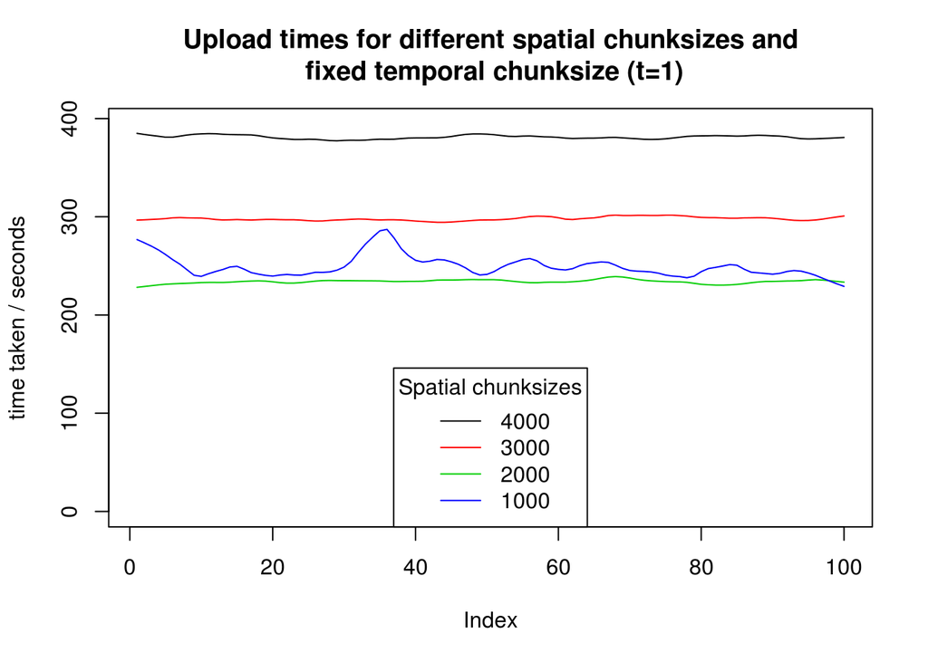

Statistical values for different spatial chunksizes and t=1

|  | average/sec | total/min |
| --- | --- | --- |
| sp=4000 | 381.2833 | 635.4722 |
| sp=3000 | 298.1415 | 496.9025 |
| sp=2000 | 234.4101 | 390.6835 |
| sp=1000 | 252.0633 | 420.1055 |

## Time consumption per upload iteration for temporal chunksize t=25

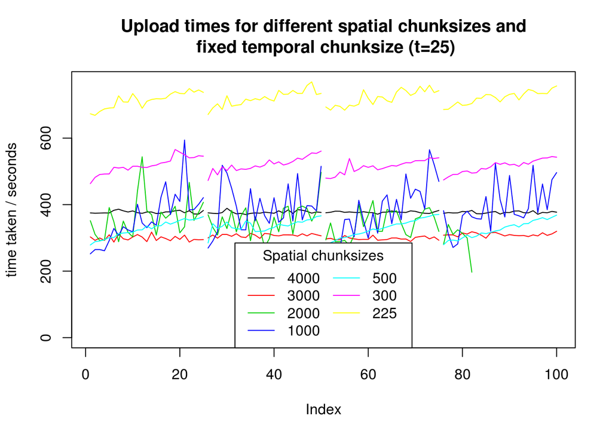

Statistical values for different spatial chunksizes and t=25

|  | average/sec | total/min |
| --- | --- | --- |
| sp=4000 | 377.1553 | 628.5922 |
| sp=3000 | 303.6220 | 506.0367 |
| sp=2000 | 347.8608 | NA |
| sp=1000 | 381.0155 | 635.0259 |
| sp=500 | 329.7043 | 549.5071 |
| sp=300 | 517.5391 | 862.5652 |
| sp=225 | 719.4904 | 1199.1507 |

## Time consumption per upload iteration for temporal chunksize t=50

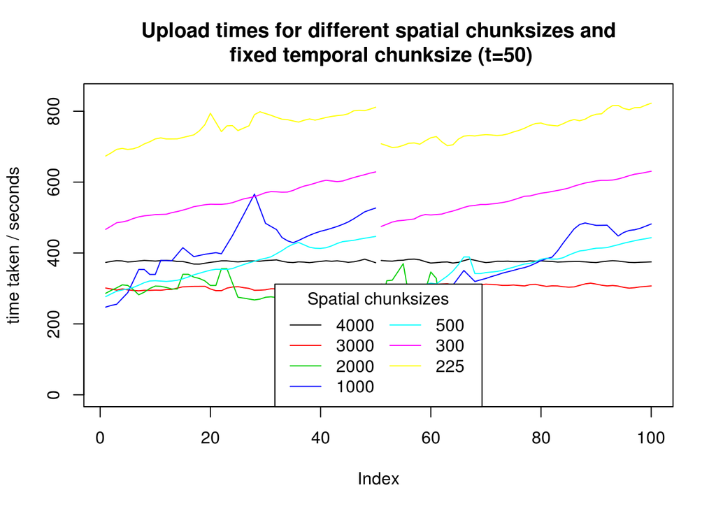

Statistical values for different spatial chunksizes and t=50

|  | average/sec | total/min |
| --- | --- | --- |
| sp=4000 | 376.1659 | 626.9432 |
| sp=3000 | 304.0302 | 506.7171 |
| sp=2000 | 293.4799 | NA |
| sp=1000 | 391.5886 | 652.6477 |
| sp=500 | 368.8422 | 614.7370 |
| sp=300 | 553.9458 | 923.2430 |
| sp=225 | 755.5692 | 1259.2819 |

## Time consumption per upload iteration for spatial chunksize sp=4000

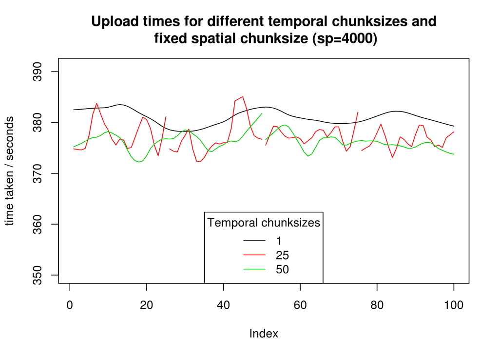

## Time consumption per upload iteration for spatial chunksize sp=3000

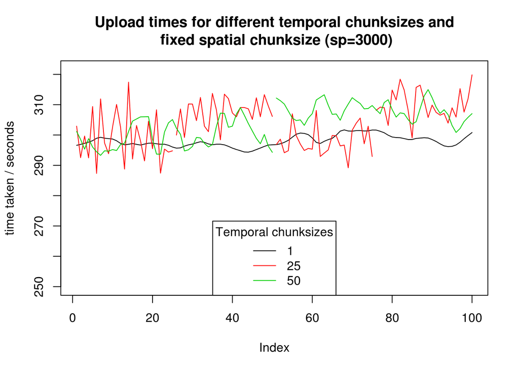

## Time consumption per upload iteration for spatial chunksize sp=2000

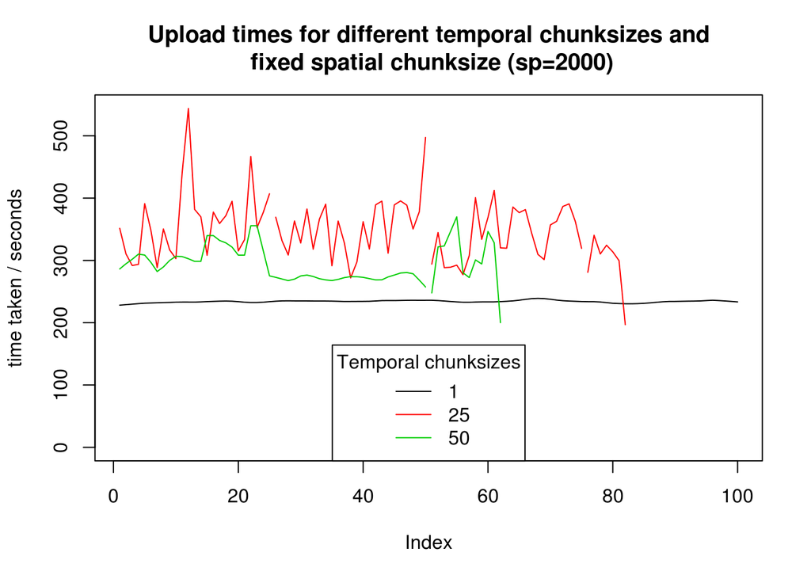

##Time consumption per upload iteration for spatial chunksize sp=1000

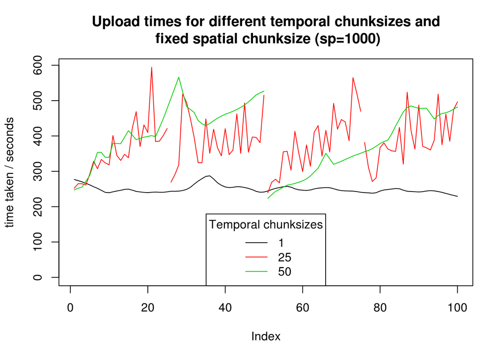

## Time consumption per upload iteration for spatial chunksize sp=500

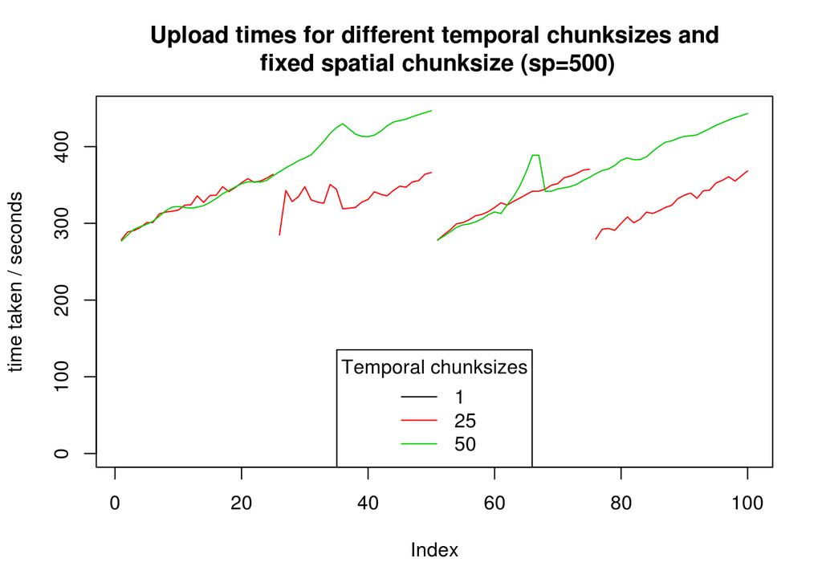

## Time consumption per upload iteration for spatial chunksize sp=300

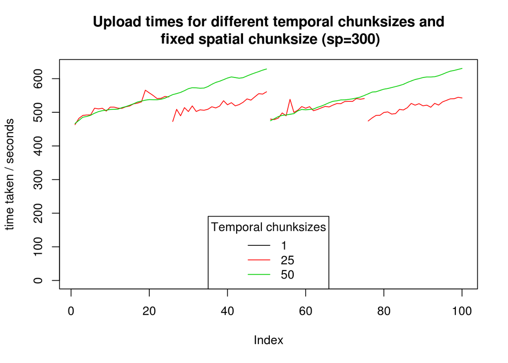

## Time consumption per upload iteration for spatial chunksize sp=225

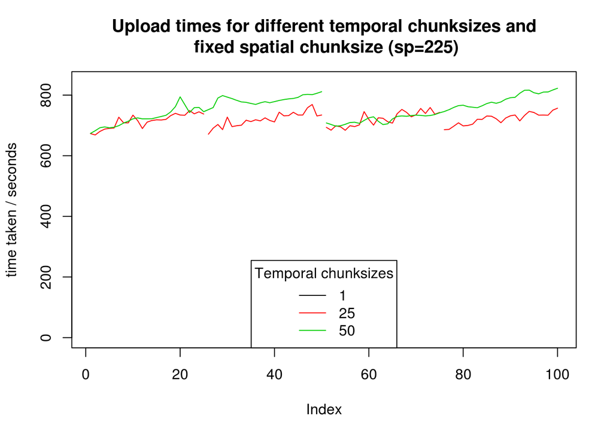

# Overall statistics

Average time consumption in seconds:

|  | sp=4000 | sp=3000 | sp=2000 | sp=1000 | sp=500 | sp=300 | sp=225 |
| --- | --- | --- | --- | --- | --- | --- | --- |
| \| t=1 \| | 381.28 | 298.14 | 234.41 | 252.06 | NA | NA | NA |
| \| t=25 \| | 377.16 | 303.62 | 347.86 | 381.02 | 329.70 | 517.54 | 719.49 |
| \| t=50 \| | 376.17 | 304.03 | 293.48 | 391.59 | 368.84 | 553.95 | 755.57 |

Total time consumption in minutes:

[output not shown]

Total time consumption in hours:

[output not shown]